# 07_lecture_linear_regression

generic_presentation

March 17th 2020

## What is Regression?

- A way of predicting the value of one variable from another.
  - It is a hypothetical model of the relationship between two variables.
  - The model used is a linear one.
  - Therefore, we describe the relationship using the equation of a straight line.

## Model for Correlation

$$Outcome_i = (bX_i) + error_i$$

- Remember we talked about how b is standardized *(correlation coefficient, r)* to be able to tell the strength of the model.
- Therefore, $r = model + strength$ instead of $M + error$.

## Describing a Straight Line

$$Y_i = b_0 + b_1X_i + \varepsilon_i$$
the $b_i$

- Regression coefficient for the predictor
- Gradient *(slope)* of the regression line
- Direction/Strength of Relationship.

the $b_0$

- Intercept (value of Y when X = 0)
- Point at which the regression line crosses the Y-axis *(ordinate)*

## Intercepts and Gradients

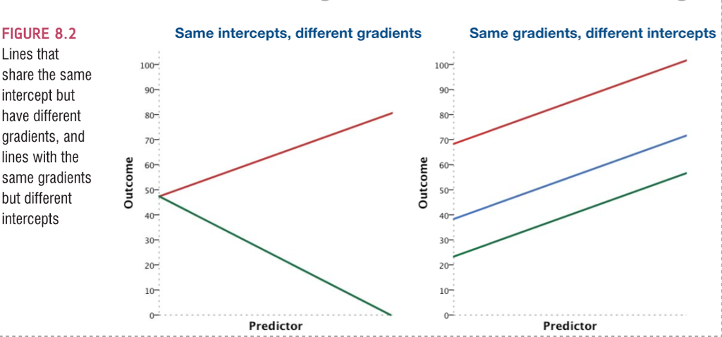

## Types of Regression

- **Simple Linear Regression = SLR**
  - One X variable (IV)
- **Multiple Linear Regression = MLR**
  - 2 or more X variables (IVs)
  - MLR types inlcude:
    - Simultaneous
      - Everything at once
    - Hierarchical
      - IVs in steps
    - Stepwise
      - Statistical regression (not recommended)

## Analyzing a Regression

- Is my overall model *(i.e. the regression equation)* useful at predicting the outcome variable?
  - Use the Models summary, ANOVA, and:

$$R^2$$

- How useful are each of the individual predictors for my model?
  - Use the Coefficients, t-test, and:

$$pr^2$$

## Overall Model

- Generally, our models will be a subtraction of different types of information.
  - SStotal = My score - Grand Mean
  - SSmodel = My level - Grand Mean
  - SSresidual = My score - My level
- This method is called *least squares*.

## The Method of Least Squares

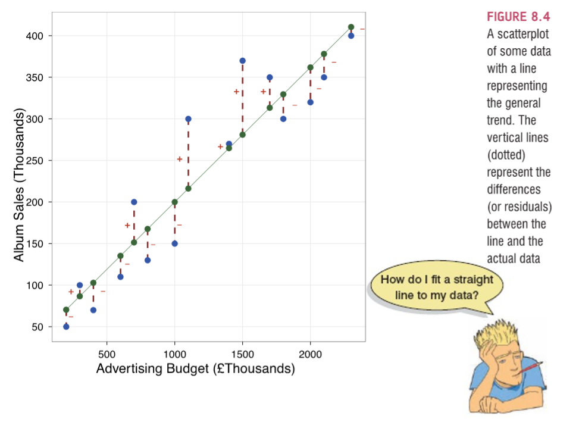

## Sums of Squares

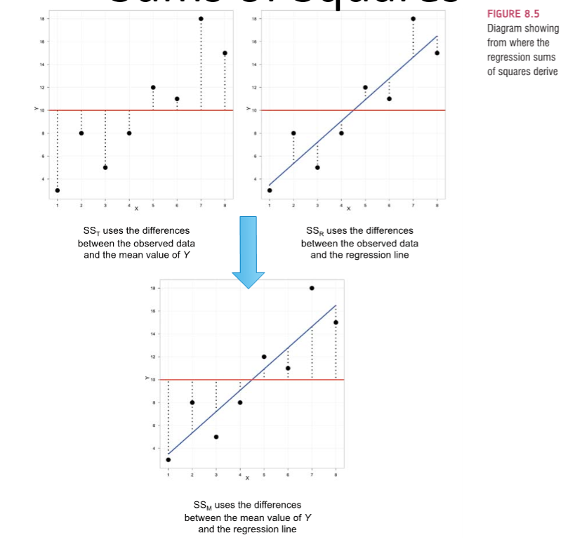

## Summary

$$SS_T$$

- Total variability *(variability between scores and the mean)*.
- My score - Grand mean

$$SS_R$$

- Residual/Error variability *(variability between the regression model and the actual data)*.
- My score - my predicted score

$$SS_M$$

- Model variability *(difference in variability between the model and the mean)*.
- My predicted score - Grand mean

## Overall Model: ANOVA

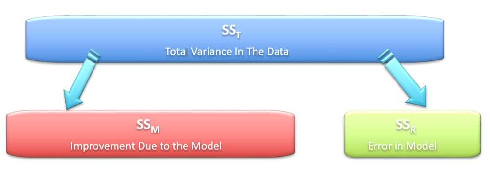

- If the model results in better prediction than using the mean, then we expect:

$$SS_M$$

- …to be much greater than:

$$SS_R$$

## Overall Model: R_Squared

$$R^2$$

- The proportion of variance accounted for by the regression model.
- The Pearson Correlation Coefficient Squared.

$$R^2 = \frac {SS_M}{SS_T}$$

## Individual Predictors

- We test the individual predictors with a t-test.
  - Think about the individual predictors as being important only if our overall model is important.
- Single sample t-test to determine if the b value is different from zero
  - $Test statistic = b / SE$

## Individual Predictors…continued.1

- t values are traditionally reported, but the df aren’t obvious in R.
- $df = N - k - 1$
- $N =$ total sample size, $k =$ number of predictors
  - So $correlation = N - 1 - 1 = N - 2$
  - *(what we did last week)*
  - Also df residual on the output *(df error)*

## Individual Predictors…continued.2

- $b =$ unstandardized regression coefficient
  - For every one unit increase in X, there will be b units increase in Y.
- $\beta =$ standardized regression coefficient
  - b in standard deviation units.
  - For every one SD increase in X, there will be $/beta$ SDs increase in Y.
- b or $\beta$? It Depends:
  - b is more interpretable given your specific problem
  - Beta is more interpretable given differences in scales for different variables.

## Data Screening

- Now we want to look specifically at the residuals for Y, while screening the X variables.
- We used a random variable before to check the continuous variable (the DV) to make sure they were randomly distributed.
- Now we don’t need the random variable because the residuals for Y should be randomly distributed (and evenly) with the X variable.
- So we get to data screen with a real regression.
  - *(rather than the fake one used in correlation and when we first practiced).*

## Data Screening…continued.1

- Missing and accuracy are still screened in the same way
- Outliers - (somewhat) new and exciting!
- Multicollinearity - same procedure
- Linearity, Normality, Homogeneity, Homoscedasticity - same procedure
- *(but now on the real regression)*

## Example

- Data = C7 regression data

```r
str(master)
```

```
## Classes 'tbl_df', 'tbl' and 'data.frame':    267 obs. of  3 variables:
##  $ PIL_total      : num  121 76 98 122 99 134 102 124 126 112 ...
##   ..- attr(*, "format.spss")= chr "F8.2"
##   ..- attr(*, "display_width")= int 11
##  $ CESD_total     : num  28 37 20 15 7 7 27 10 9 8 ...
##   ..- attr(*, "format.spss")= chr "F8.2"
##   ..- attr(*, "display_width")= int 12
##  $ AUDIT_TOTAL_NEW: num  1 5 3 3 2 3 2 1 1 7 ...
##   ..- attr(*, "format.spss")= chr "F8.2"
##   ..- attr(*, "display_width")= int 17
```

## Example…continued.1

- Understanding your variables.
  - CESD = depression measure
  - PIL total = measure of meaning in life
  - AUDIT total = measure of alcoholism
  - DAST total = measure of drug usage

## Example - Run the Regression

- You know that LM function we’ve been using?
- Yes! You get to use it again.
- Same $Y ~ X + X$ format we’ve been using.

## Example - Run the Regression…continued.1

```r
model1 = lm(CESD_total ~ PIL_total + AUDIT_TOTAL_NEW, data = master)
```

```r
summary(model1)
```

```
##
## Call:
## lm(formula = CESD_total ~ PIL_total + AUDIT_TOTAL_NEW, data = master)
##
## Residuals:
##     Min      1Q  Median      3Q     Max
## -16.064  -5.351  -1.590   3.375  29.490
##
## Coefficients:
##                 Estimate Std. Error t value Pr(>|t|)
## (Intercept)     56.07766    3.90669  14.354   <2e-16 ***
## PIL_total       -0.38892    0.03401 -11.435   <2e-16 ***
## AUDIT_TOTAL_NEW  0.02444    0.08181   0.299    0.765
## ---
## Signif. codes:  0 '***' 0.001 '**' 0.01 '*' 0.05 '.' 0.1 ' ' 1
##
## Residual standard error: 7.689 on 264 degrees of freedom
## Multiple R-squared:  0.337,  Adjusted R-squared:  0.332
## F-statistic: 67.11 on 2 and 264 DF,  p-value: < 2.2e-16
```

## Example - Data Screening

- First, Check for missing data:

```r
summary(master)
```

```
##    PIL_total       CESD_total   AUDIT_TOTAL_NEW
##  Min.   : 60.0   Min.   : 0.0   Min.   : 0.000
##  1st Qu.:103.0   1st Qu.: 7.0   1st Qu.: 2.000
##  Median :111.0   Median :11.0   Median : 5.000
##  Mean   :110.7   Mean   :13.2   Mean   : 6.807
##  3rd Qu.:121.0   3rd Qu.:17.0   3rd Qu.:11.000
##  Max.   :138.0   Max.   :47.0   Max.   :31.000
```

## Example - Data Screening…continued.1

- Next, let’s do **Mahalanobis**
  - Same rules apply with mahalanobis() function
  - But now we are going to save a column of data that includes if they are above the cut off score or not.

```r
mahal = mahalanobis(master,
                    colMeans(master),
                    cov(master))
cutmahal = qchisq(1-.001, ncol(master))
badmahal = as.numeric(mahal > cutmahal) ##note the direction of the >
table(badmahal)
```

```
## badmahal
##   0   1
## 266   1
```

## Example - Data Screening…continued.2

- **Outliers**
  - Leverage - influence of that person on the slope
- What do these numbers mean? $Cut off = (2K+2)/N$
- To get them in R
  - hatvalues(model)

```r
k = 2 ##number of IVs
leverage = hatvalues(model1)
cutleverage = (2*k+2) / nrow(master)
badleverage = as.numeric(leverage > cutleverage)
table(badleverage)
```

```
## badleverage
##   0   1
## 251  16
```

## Example - Data Screening…continued.3

- **Outliers**
  - Influence **(Cook’s values)** - a measure of how much of an effect that single case has on the whole model
  - Often described as leverage + discrepancy
- What do the numbers mean?
  - $Cut off = 4/(N-K-1)$
- To get them in R
  - cooks.distance(model)

```r
cooks = cooks.distance(model1)
cutcooks = 4 / (nrow(master) - k - 1)
badcooks = as.numeric(cooks > cutcooks)
table(badcooks)
```

```
## badcooks
##   0   1
## 250  17
```

## Example - Data Screening…continued.4

- What do I do with all these numbers?!
  - Screen those bad boys, and add it up!
  - Subset out the bad people!

```r
##add them up!
totalout = badmahal + badleverage + badcooks
table(totalout)
```

```
## totalout
##   0   1   2   3
## 240  21   5   1
```

```r
##get rid of them!
noout = subset(master, totalout < 2)
```

## Example - Data Screening…continued.5

- Ok now that we got rid of outliers, we need to run that model again.
- otherwise the next set of assumption tests is wrong and includes those people.

```r
model2 = lm(CESD_total ~ PIL_total + AUDIT_TOTAL_NEW, data = noout)
```

```r
summary(model2)
```

```
##
## Call:
## lm(formula = CESD_total ~ PIL_total + AUDIT_TOTAL_NEW, data = noout)
##
## Residuals:
##     Min      1Q  Median      3Q     Max
## -13.535  -5.172  -1.545   3.168  29.820
##
## Coefficients:
##                 Estimate Std. Error t value Pr(>|t|)
## (Intercept)     54.31164    4.16332  13.045   <2e-16 ***
## PIL_total       -0.37281    0.03603 -10.346   <2e-16 ***
## AUDIT_TOTAL_NEW  0.00120    0.08315   0.014    0.988
## ---
## Signif. codes:  0 '***' 0.001 '**' 0.01 '*' 0.05 '.' 0.1 ' ' 1
##
## Residual standard error: 7.422 on 258 degrees of freedom
## Multiple R-squared:  0.298,  Adjusted R-squared:  0.2926
## F-statistic: 54.77 on 2 and 258 DF,  p-value: < 2.2e-16
```

## Example - Data Screening…continued.6

- **Multicollinearity**
  - You want X and Y to be correlated
  - You do not want the Xs to be highly correlated
    - It’s a waste of power (dfs)

```r
summary(model2, correlation = TRUE)
```

```
##
## Call:
## lm(formula = CESD_total ~ PIL_total + AUDIT_TOTAL_NEW, data = noout)
##
## Residuals:
##     Min      1Q  Median      3Q     Max
## -13.535  -5.172  -1.545   3.168  29.820
##
## Coefficients:
##                 Estimate Std. Error t value Pr(>|t|)
## (Intercept)     54.31164    4.16332  13.045   <2e-16 ***
## PIL_total       -0.37281    0.03603 -10.346   <2e-16 ***
## AUDIT_TOTAL_NEW  0.00120    0.08315   0.014    0.988
## ---
## Signif. codes:  0 '***' 0.001 '**' 0.01 '*' 0.05 '.' 0.1 ' ' 1
##
## Residual standard error: 7.422 on 258 degrees of freedom
## Multiple R-squared:  0.298,  Adjusted R-squared:  0.2926
## F-statistic: 54.77 on 2 and 258 DF,  p-value: < 2.2e-16
##
## Correlation of Coefficients:
##                 (Intercept) PIL_total
## PIL_total       -0.98
## AUDIT_TOTAL_NEW -0.28        0.15
```

## Example - Data Screening…continued.7

- Assumptions:

```r
standardized = rstudent(model2)
print(head(standardized))
```

```
##          1          2          3          4          5          6
##  2.5717427  0.3002151  0.8336221 -1.4125896  0.3581905  1.4533006
```

```r
fitted = scale(model2$fitted.values)
print(head(fitted))
```

```
##         [,1]
## 1 -0.7376844
## 2  1.0425536
## 3 -0.8145663
## 4  0.9649246
## 5 -1.7431262
## 6  0.7327846
```

## Example - Data Screening…continued.8

- Linearity

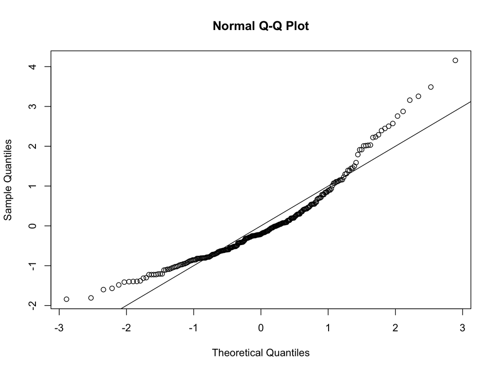

```r
qqnorm(standardized)
abline(0,1)
```

## Example - Data Screening…continued.9

- Normality

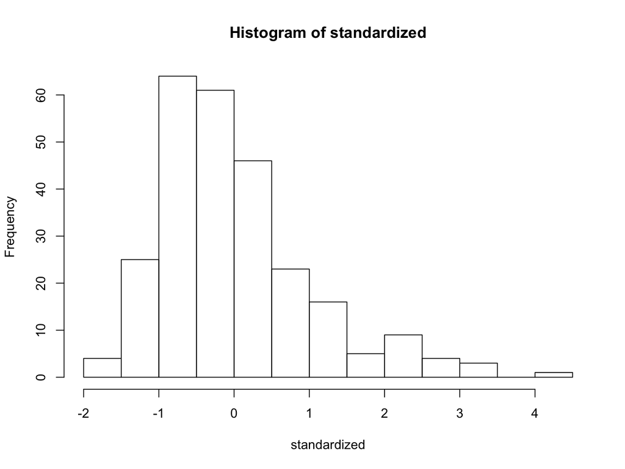

```r
hist(standardized)
```

## Example - Data Screening…continued.10

- Homogeneity & Homoscedasticity

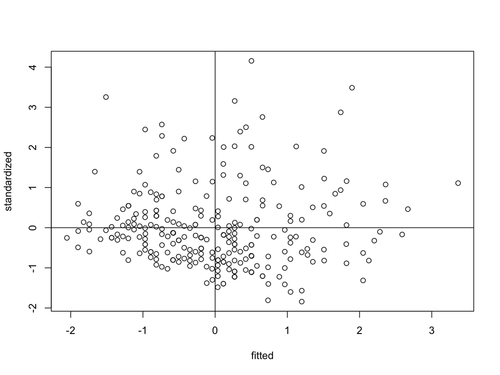

```r
plot(fitted, standardized)
abline(0,0)
abline(v = 0)
```

## Example - What to do?

- If your assumptions go wrong:
  - Linearity - try nonlinear regression or nonparametric regression
  - Normality - more subjects, still fairly robust
  - Homogeneity/Homoscedasticity - bootstrapping

## Example - Overall Model

- After data screening, we want to know if our regression worked!
  - Start with the overall model - is it significant?
  - summary(model)

```r
summary(model2)
```

```
##
## Call:
## lm(formula = CESD_total ~ PIL_total + AUDIT_TOTAL_NEW, data = noout)
##
## Residuals:
##     Min      1Q  Median      3Q     Max
## -13.535  -5.172  -1.545   3.168  29.820
##
## Coefficients:
##                 Estimate Std. Error t value Pr(>|t|)
## (Intercept)     54.31164    4.16332  13.045   <2e-16 ***
## PIL_total       -0.37281    0.03603 -10.346   <2e-16 ***
## AUDIT_TOTAL_NEW  0.00120    0.08315   0.014    0.988
## ---
## Signif. codes:  0 '***' 0.001 '**' 0.01 '*' 0.05 '.' 0.1 ' ' 1
##
## Residual standard error: 7.422 on 258 degrees of freedom
## Multiple R-squared:  0.298,  Adjusted R-squared:  0.2926
## F-statistic: 54.77 on 2 and 258 DF,  p-value: < 2.2e-16
```

## Example - What about the predictors?

- Look in the coefficients section.

```r
summary(model2)
```

```
##
## Call:
## lm(formula = CESD_total ~ PIL_total + AUDIT_TOTAL_NEW, data = noout)
##
## Residuals:
##     Min      1Q  Median      3Q     Max
## -13.535  -5.172  -1.545   3.168  29.820
##
## Coefficients:
##                 Estimate Std. Error t value Pr(>|t|)
## (Intercept)     54.31164    4.16332  13.045   <2e-16 ***
## PIL_total       -0.37281    0.03603 -10.346   <2e-16 ***
## AUDIT_TOTAL_NEW  0.00120    0.08315   0.014    0.988
## ---
## Signif. codes:  0 '***' 0.001 '**' 0.01 '*' 0.05 '.' 0.1 ' ' 1
##
## Residual standard error: 7.422 on 258 degrees of freedom
## Multiple R-squared:  0.298,  Adjusted R-squared:  0.2926
## F-statistic: 54.77 on 2 and 258 DF,  p-value: < 2.2e-16
```

## Example - What about the predictors?…continued

- Meaning was significant:
  - b = -0.37,
  - t(258) = -10.35,
  - p < .001
- Alcohol was not:
  - b = 0.001,
  - t(258) = 0.01,
  - p = .99

## Example - Predictors

- Two concerns:
  - What if I wanted to use beta because these are very different scales?
  - What about an effect size for each individual predictor?

## Example - Predictors - Beta

- You will need the QuantPsyc package for beta.
- lm.beta(model)

```r
library(QuantPsyc)
lm.beta(model2)
```

```
##       PIL_total AUDIT_TOTAL_NEW
##   -0.5458229582    0.0007613226
```

## Example - R

- Multiple correlations = R
- All overlap in Y
  - $A+B+C/(A+B+C+D)$

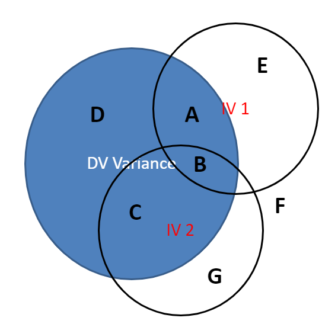

## Example - SR

- Semipartial correlations = sr
- Unique contribution of IV to $R^2$ for those IVs
  - Increase in proportion of explained Y variance when X is added to the equation
  - $A/(A+B+C+D)$

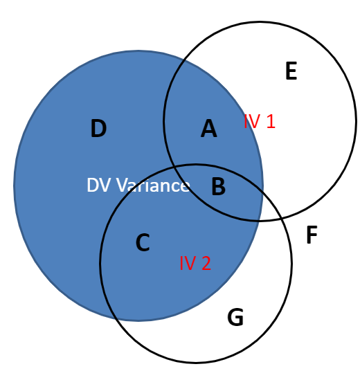

## Example - PR

- Partial correlation = pr
  - Proportion in variance in Y not explained by other predictors but this X only
  - $A/(A+D)$
  - Pr > sr

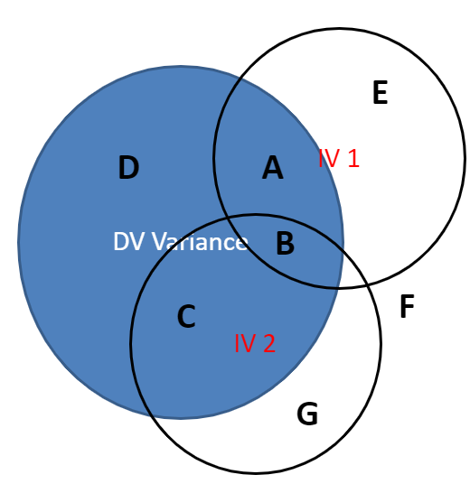

## Example - Predictors - Partials

- Remember to square them!
- New code, so you don’t forget:
  - partials = pcor(dataset)
  - partials$estimate^2

```r
##you can just run the correlations but this code will help you remember to square it
library(ppcor)
partials = pcor(noout)
partials$estimate^2
```

```
##                  PIL_total   CESD_total AUDIT_TOTAL_NEW
## PIL_total       1.00000000 2.932416e-01    1.571336e-02
## CESD_total      0.29324157 1.000000e+00    8.072129e-07
## AUDIT_TOTAL_NEW 0.01571336 8.072129e-07    1.000000e+00
```

## Example - Predictors - Partials…continued.1

- Meaning was significant:

$$b = -0.37, t(258) = -10.35, p < .001, pr^2 = .29$$

- Alcohol was not:

$$b = 0.001, t(258) = 0.01, p = .99, pr^2 < .01$$

## Hierarchical Regression - Dummy Coding

- **Hierarchical Regression**
  - Known predictors (based on past research) are entered into the regression model first.
  - New predictors are then entered in a separate step/block.
  - Experimenter makes the decisions.
- **It is the best method:**
  - Based on theory testing.
  - You can see the unique predictive influence of a new variable on the outcome because known predictors are held constant in the model.
- **Bad Point:**
  - Relies on the experimenter knowing what they’re doing!

## Hierarchical Regression - What Does It Answer?

- **Answers the following questions:**
  - Is my overall model significant?
  - Is the addition of each step significant?
  - Are the individual predictors significant?
- **Uses:**
  - When a researcher wants to control for some known variables first.
  - When a researcher wants to see the incremental value of different variables.
  - When a researcher wants to discuss groups of variables together *(SETS –> especially good for highly correlated variables).*
  - When a researcher wants to use categorical variables with many categories *(use as a SET).*

## Hierarchical Regression - Categorical Predictors

- So what do you do when you have predictors with more than 2 categories?
- DUMMY CODING
  - Cool news: If your variable is factored in R, it does that for you automatically.

## Hierarchical Regression - Dummy Coding

- How many dummy coded variables will you get for a categorical variable?
  - Number of categories - 1
- The all zero group is the control group or comparison group.

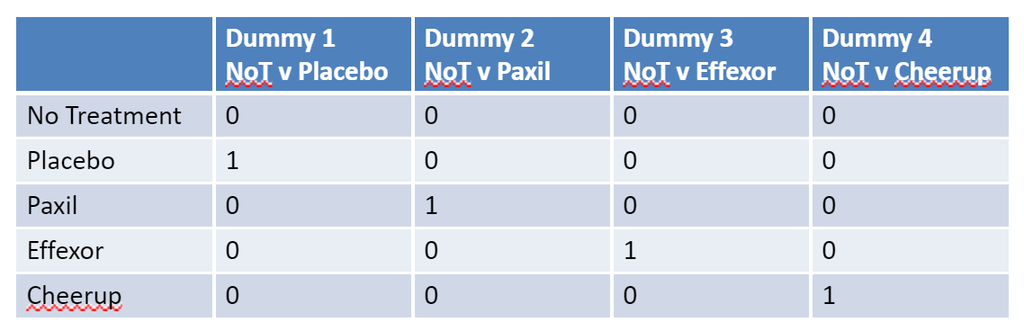

## Hierarchical Regression - Hierarchical/Categorical Predictors

- Example!
  - C7 dummy code.sav

```r
library(haven)
hdata = read_spss("data/c7 dummy code.sav")
```

```r
summary(hdata)
```

```
##      treat   familyhistory        after
##  Min.   :0   Min.   : 0.390   Min.   : 5.00
##  1st Qu.:1   1st Qu.: 6.812   1st Qu.:11.00
##  Median :2   Median :14.580   Median :13.00
##  Mean   :2   Mean   :13.690   Mean   :13.10
##  3rd Qu.:3   3rd Qu.:20.055   3rd Qu.:15.75
##  Max.   :4   Max.   :32.270   Max.   :19.00
```

- IVs:
  - Family history of depression
  - Treatment for depression (categorical)
- DV:
  - Rating of depression after treatment

## Hierarchical Regression - Hierarchical/Categorical Predictors…continued.1

- Remember categorical variables should be factored and read_spss ignores that.

```r
attributes(hdata$treat)
```

```
## $label
## [1] "Treatment"
##
## $format.spss
## [1] "F8.0"
##
## $display_width
## [1] 18
##
## $class
## [1] "haven_labelled"
##
## $labels
##    No Treatment         Placebo Seroxat (Paxil)         Effexor
##               0               1               2               3
##         Cheerup
##               4
```

```r
hdata$treat = factor(hdata$treat,
                     levels = 0:4,
                     labels = c("No Treatment", "Placebo", "Paxil",
                                "Effexor", "Cheerup"))
```

## Hierarchical Regression - Hierarchical/Categorical Predictors…continued.2

- **First model** = after ~ family history
  - Controls for family history before testing if treatment is significant

```r
model1 = lm(after ~ familyhistory, data = hdata)
```

- **Second model** = after ~ family history + treatment

```r
model2 = lm(after ~ familyhistory + treat, data = hdata)
```

- Remember you have to leave in the family history variable or you aren’t actually controlling for it.

## Hierarchical Regression - Hierarchical/Categorical Predictors…continued.3

- **Model 1**

```r
summary(model1)
```

```
##
## Call:
## lm(formula = after ~ familyhistory, data = hdata)
##
## Residuals:
##     Min      1Q  Median      3Q     Max
## -6.5120 -1.9028 -0.2193  2.0544  6.7958
##
## Coefficients:
##               Estimate Std. Error t value Pr(>|t|)
## (Intercept)   11.00363    0.84477  13.026   <2e-16 ***
## familyhistory  0.15313    0.05254   2.915   0.0054 **
## ---
## Signif. codes:  0 '***' 0.001 '**' 0.01 '*' 0.05 '.' 0.1 ' ' 1
##
## Residual standard error: 3.133 on 48 degrees of freedom
## Multiple R-squared:  0.1504, Adjusted R-squared:  0.1327
## F-statistic: 8.495 on 1 and 48 DF,  p-value: 0.005396
```

- Model 1 is significant:

$$F(1,48) = 8.50, p = .005, R^2 = .15$$

- Family history is significant:

$$b = 0.15, t(48) = 2.92, p = .005, Pr^2 = .15$$

## Hierarchical Regression - Hierarchical/Categorical Predictors…continued.4

- **Model 2**

```r
summary(model2)
```

```
##
## Call:
## lm(formula = after ~ familyhistory + treat, data = hdata)
##
## Residuals:
##     Min      1Q  Median      3Q     Max
## -5.7908 -1.6690  0.0508  1.6674  5.4108
##
## Coefficients:
##               Estimate Std. Error t value Pr(>|t|)
## (Intercept)   13.98816    1.09637  12.759  < 2e-16 ***
## familyhistory  0.13513    0.05088   2.656 0.010973 *
## treatPlacebo  -4.09905    1.21381  -3.377 0.001542 **
## treatPaxil    -2.03744    1.22146  -1.668 0.102411
## treatEffexor  -2.59078    1.26984  -2.040 0.047356 *
## treatCheerup  -4.96339    1.22489  -4.052 0.000203 ***
## ---
## Signif. codes:  0 '***' 0.001 '**' 0.01 '*' 0.05 '.' 0.1 ' ' 1
##
## Residual standard error: 2.714 on 44 degrees of freedom
## Multiple R-squared:  0.4154, Adjusted R-squared:  0.349
## F-statistic: 6.254 on 5 and 44 DF,  p-value: 0.0001832
```

```
- I can see that the overall model is significant

- But what if the first model was significant and then this model isn't actually any better and it's just overall significant because the first model was. _(or basically how one variable runs the show)._
```

## Hierarchical Regression - Hierarchical/Categorical Predictors…continued.5

- Compare models with the anova() function.
  - You want to show the addition of your treatment variable added significantly to the equation.
  - Basically is the change in

$$R^2 > 0 ?$$

- Yes, it was significant:

$$\Delta F(4, 44) = 4.99, p = .002, \Delta R^2 = .27$$

- So the addition of the treatment set was significant.

```r
anova(model1, model2)
```

```
## Analysis of Variance Table
##
## Model 1: after ~ familyhistory
## Model 2: after ~ familyhistory + treat
##   Res.Df    RSS Df Sum of Sq      F   Pr(>F)
## 1     48 471.12
## 2     44 324.13  4    146.99 4.9883 0.002102 **
## ---
## Signif. codes:  0 '***' 0.001 '**' 0.01 '*' 0.05 '.' 0.1 ' ' 1
```

## Hierarchical Regression - Categorical Predictors

- Remember dummy coding equals:
  - Control group to coded group
  - Therefore negative numbers = coded group is lower
  - Positive numbers = coded group is higher
  - b = difference in means
  - Use tapply() to find the means **

## Hierarchical Regression - Categorical Predictors…continued.1

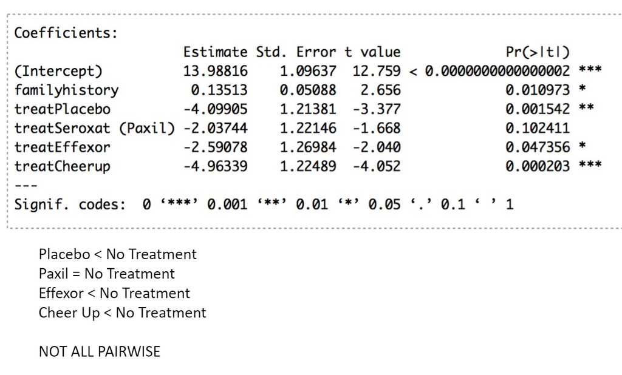

## Hierarchical Regression - Categorical Predictors…continued.2

- You could do pr sqaured for each pairwise grouping
  - (t2) / (t2 + df residual)
  - Or you could calculate cohen’s d, since these are mean comparisons.

```r
with(hdata, tapply(after, treat, mean))
```

```
## No Treatment      Placebo        Paxil      Effexor      Cheerup
##         15.8         11.7         13.4         14.2         10.4
```

```r
with(hdata, tapply(after, treat, sd))
```

```
## No Treatment      Placebo        Paxil      Effexor      Cheerup
##     2.973961     2.750757     2.951459     3.084009     2.674987
```

```r
with(hdata, tapply(after, treat, length))
```

```
## No Treatment      Placebo        Paxil      Effexor      Cheerup
##           10           10           10           10           10
```

## Hierarchical Regression - Categorical Predictors…continued.3

- get pr squared for this type of data

```r
t = 2.040
dfresidual = 44

t^2 / (t^2+dfresidual)
```

```
## [1] 0.08640909
```

## Hierarchical Regression - Power

- pwr.f2.test(u = df model,
  - v = NULL,
  - f2 = converted f value,
  - sig.level = .05,
  - power = .80)

## Hierarchical Regression - Power…continued.1

```r
library(pwr)
##power runs on cohen's f - not to be confused with anova f.
##take the R squared to convert
R2 =  0.4154
feta = R2 / (1-R2)

#u is df model
#v is df error, but we are trying to figure out sample size for each condition,
##so we leave this one blank.
#f2 is cohen f squared
```

```r
pwr.f2.test(u = 5, v = NULL, f2 = feta, sig.level = .05, power = .80)
```

```
##
##      Multiple regression power calculation
##
##               u = 5
##               v = 18.23385
##              f2 = 0.7105713
##       sig.level = 0.05
##           power = 0.8
```

- *Remember sample size is v + k + 1 where k is the predictors*

## Alternative - Regression using Caret Package for Cross Validation

- Cross Validation allows us to speak to the accuracy of our model across datasets but requires several steps
- 1. Create training and validation datasets
- 2. Run your model with the training data
- 3. Evaluaute the quality of the model with the validation set
- 4. Repeate the first three steps several times (the caret package will do this for us!)
- 5. Evaluaute the quality of the model with the averaged values from the validation set (we will compare RMSE, Rsquared, and MAE)

## Alternative - Regression using Caret Package for Cross Validation.1

- Install the package and upload it into the enviroment!

```r
library(caret)
```

- Regression using Caret requires training.
  - Split the data for cross validation.
  - Create a list of 80% of the rows in the Original dataset we can use for training

**Model 1:**

- No Data Screening except for checking for missing.

```r
validation_index1 = createDataPartition(master$CESD_total, p =0.80, list = FALSE)
dim(validation_index1)
```

```
## [1] 215   1
```

**Model 2:**

- Data Screened dataset “noout”.

```r
validation_index2 = createDataPartition(noout$CESD_total, p =0.80, list = FALSE)
dim(validation_index2)
```

```
## [1] 211   1
```

## Alternative - Regression using Caret …continued.1

- Select 20% of the data for validation

```r
Validation1 = master[-validation_index1,]
dim(Validation1)
```

```
## [1] 52  3
```

```r
Validation2 = noout[-validation_index2,]
dim(Validation2)
```

```
## [1] 50  3
```

- Use the remaining 80% of the data to training and testing the models

```r
dataset1 = master[validation_index1,]
dim(dataset1)
```

```
## [1] 215   3
```

```r
dataset2 = noout[validation_index2,]
dim(dataset2)
```

```
## [1] 211   3
```

## Alternative - Regression using Caret …continued.2

- Summarize the Data

**Data for Model One:**

```r
dim(dataset1)
```

```
## [1] 215   3
```

```r
dim(Validation1)
```

```
## [1] 52  3
```

**Date for Model 2:**

```r
dim(dataset2)
```

```
## [1] 211   3
```

```r
dim(Validation2)
```

```
## [1] 50  3
```

## Alternative - Regression using Caret …continued.3

- Check for Missing

```r
apply(dataset1,2,function(x) sum(is.na(x)))
```

```
##       PIL_total      CESD_total AUDIT_TOTAL_NEW
##               0               0               0
```

```r
apply(Validation1,2,function(x) sum(is.na(x)))
```

```
##       PIL_total      CESD_total AUDIT_TOTAL_NEW
##               0               0               0
```

```r
apply(dataset2,2,function(x) sum(is.na(x)))
```

```
##       PIL_total      CESD_total AUDIT_TOTAL_NEW
##               0               0               0
```

```r
apply(Validation2,2,function(x) sum(is.na(x)))
```

```
##       PIL_total      CESD_total AUDIT_TOTAL_NEW
##               0               0               0
```

## Alternative - Regression using Caret …continued.4

- Set the Test Harness using 10-fold cross validation.

```r
control <- trainControl(method="cv", number=10)
```

- Build the Model:

**Model 1:**

```r
set.seed(7)
fit.lm1 <- train(CESD_total ~ PIL_total + AUDIT_TOTAL_NEW, data = dataset1, method="lm", trControl = control)
```

**Model 2:**

```r
set.seed(7)
fit.lm2 <- train(CESD_total ~ PIL_total + AUDIT_TOTAL_NEW, data = dataset2, method="lm", trControl = control)
```

## Alternative - Regression using Caret …continued.5

- Print the summary of the model:

**Model 1:**

```r
print(fit.lm1)
```

```
## Linear Regression
##
## 215 samples
##   2 predictor
##
## No pre-processing
## Resampling: Cross-Validated (10 fold)
## Summary of sample sizes: 193, 194, 193, 194, 194, 194, ...
## Resampling results:
##
##   RMSE     Rsquared   MAE
##   7.76508  0.3566249  5.969608
##
## Tuning parameter 'intercept' was held constant at a value of TRUE
```

## Alternative - Regression using Caret …continued.6

**Model 2:**

```r
print(fit.lm2)
```

```
## Linear Regression
##
## 211 samples
##   2 predictor
##
## No pre-processing
## Resampling: Cross-Validated (10 fold)
## Summary of sample sizes: 188, 191, 190, 190, 188, 190, ...
## Resampling results:
##
##   RMSE      Rsquared   MAE
##   7.653315  0.2807288  5.790632
##
## Tuning parameter 'intercept' was held constant at a value of TRUE
```

## Alternative - Regression using Caret …continued.7

- Retrieve coefficients for
  - slope
  - intercept

**Model 1:**

```r
coef.icept1 <- coef(fit.lm1$finalModel)[1]
print(coef.icept1)
```

```
## (Intercept)
##    54.82236
```

```r
coef.slope1 <- coef(fit.lm1$finalModel)[2]
print(coef.slope1)
```

```
##  PIL_total
## -0.3849462
```

## Alternative - Regression using Caret …continued.8

**Model 2:**

```r
coef.icept2 <- coef(fit.lm2$finalModel)[1]
print(coef.icept2)
```

```
## (Intercept)
##    52.31943
```

```r
coef.slope2 <- coef(fit.lm2$finalModel)[2]
print(coef.slope2)
```

```
##  PIL_total
## -0.3567209
```

## Alternative - Regression using Caret …continued.9

- We can view the model predictions for each fold

**Model 1:**

```r
fit.lm1$resample
```

```
##        RMSE  Rsquared      MAE Resample
## 1  6.229628 0.5133297 5.344953   Fold01
## 2  6.653776 0.3477135 5.471341   Fold02
## 3  7.411417 0.4031098 5.164060   Fold03
## 4  8.303130 0.3910857 6.457370   Fold04
## 5  9.639553 0.2342610 6.628675   Fold05
## 6  9.554004 0.3494785 7.651361   Fold06
## 7  6.800746 0.5187975 5.289437   Fold07
## 8  6.852230 0.2555979 5.213036   Fold08
## 9  8.636085 0.3756128 6.261302   Fold09
## 10 7.570234 0.1772627 6.214546   Fold10
```

**Model 2:**

```r
fit.lm2$resample
```

```
##        RMSE   Rsquared      MAE Resample
## 1  9.904121 0.13677913 7.144117   Fold01
## 2  6.228657 0.26640170 4.524552   Fold02
## 3  6.882400 0.13339215 5.651792   Fold03
## 4  5.593089 0.46946051 4.496464   Fold04
## 5  6.996688 0.31413878 5.689559   Fold05
## 6  7.520512 0.07307732 6.158383   Fold06
## 7  8.450444 0.48929514 6.042937   Fold07
## 8  9.914225 0.17235702 6.831014   Fold08
## 9  7.627004 0.50656116 5.428806   Fold09
## 10 7.416015 0.24582503 5.938696   Fold10
```

- We can also view the standard deviaion around the Rsquared value by looking at the Rsquared from each fold

**Model 1:**

```r
sd(fit.lm1$resample$Rsquared)
```

```
## [1] 0.1115776
```

**Model 2:**

```r
sd(fit.lm2$resample$Rsquared)
```

```
## [1] 0.1598446
```

## Alternative - Regression using Caret …continued.10

- Estimate the performance of the models using the validation set:

**Model 1:**

```r
predictions1 = predict(fit.lm1, Validation1)
```

```r
postResample(pred = predictions1, obs = Validation1$CESD_total)
```

```
##     RMSE Rsquared      MAE
## 7.307670 0.321614 5.305304
```

**Model 2:**

```r
predictions2 = predict(fit.lm2, Validation2)
```

```r
postResample(pred = predictions2, obs = Validation2$CESD_total)
```

```
##      RMSE  Rsquared       MAE
## 5.8908469 0.5106757 4.8583648
```

## Note Using Caret

- The $R^2$ is calculated:
  - “…computing the correlation between the observed and predicted values (i.e. R) and squaring the value.”

**Source:** [link] http://topepo.github.io/caret/measuring-performance.html#measures-for-regression